# RegressionTree_prostata

# Regression tree

## Modeling and evaluation

To perform the modeling process, we will need to load seven different R packages. Then, we will go through each of the techniques and compare how well they perform on the data analyzed with the prior methods in the previous chapters.

We will jump right in to the prostate dataset, but let’s first load the necessary R packages. As always, please ensure that you have the libraries installed prior to loading the packages:

```r
 library(rpart) #classification and regression trees
 library(partykit) #treeplots
 library(MASS) #breast and pima indian data
 library(ElemStatLearn) #prostate data
 library(randomForest) #random forests
 library(gbm) #gradient boosting
 library(caret) #tune hyper-parameters
```

We will first do regression with the prostate data and prepare it as we did in Chapter 4, Advanced Feature Selection in Linear Models. This involves calling the dataset, coding the gleason score as an indicator variable using the ifelse() function, and creating the test and train sets. The train set will be pros.train and the test set will be pros.test, as follows:

```r
 data(prostate)
 prostate$gleason = ifelse(prostate$gleason == 6, 0, 1)
 pros.train = subset(prostate, train==TRUE)[,1:9]
 pros.test = subset(prostate, train==FALSE)[,1:9]
```

## Build a regression tree on the train data

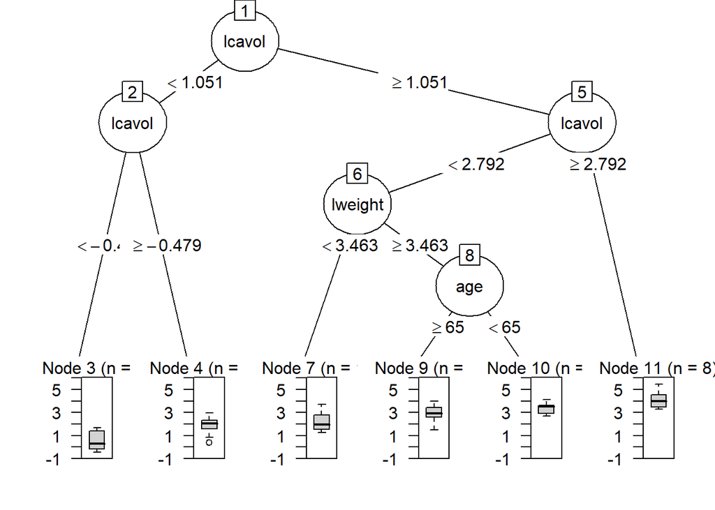

```r
 tree.pros = rpart(lpsa~., data=pros.train)
 plot(as.party(tree.pros))
```

## Determine the optimal number of splits in the tree

We can call this object using the print() function and cptable and then examine the error per split in order to determine the optimal number of splits in the tree:

```r
 print(tree.pros$cptable)
```

```
##           CP nsplit rel error    xerror      xstd
## 1 0.35852251      0 1.0000000 1.0204861 0.1790543
## 2 0.12295687      1 0.6414775 0.9914133 0.1270769
## 3 0.11639953      2 0.5185206 0.8190209 0.1231401
## 4 0.05350873      3 0.4021211 0.7815974 0.1199371
## 5 0.01032838      4 0.3486124 0.7148893 0.1064097
## 6 0.01000000      5 0.3382840 0.7184485 0.1063337
```

This is a very important table to analyze. The first column labeled CP is the cost complexity parameter. The second column, nsplit, is the number of splits in the tree. The rel error column stands for relative error and is the RSS for the number of splits divided by the RSS for no splits RSS(k)/RSS(0). Both xerror and xstd are based on the ten-fold cross-validation with xerror being the average error and xstd the standard deviation of the cross-validation process. We can see that while five splits produced the lowest error on the full dataset, four splits produced a slightly less error using cross-validation. You can examine this using plotcp():

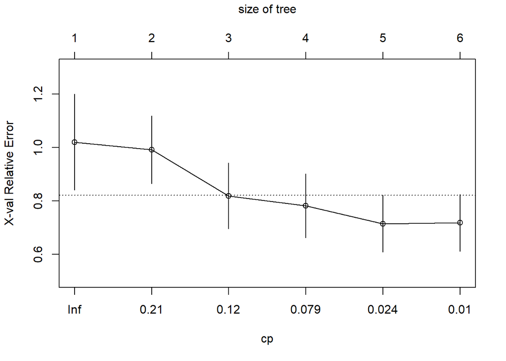

```r
 plotcp(tree.pros)
```

## Pruning tree with lowest xerror

The output of the preceding command is as follows: The plot shows us the relative error by the tree size with the corresponding error bars. The horizontal line on the plot is the upper limit of the lowest standard error. Selecting a tree size, 5, which is four splits, we can build a new tree object where xerror is minimized by pruning our tree accordingly by first creating an object for cp associated with the pruned tree from the table. Then the prune() function handles the rest:

```r
 cp = min(tree.pros$cptable[5,])
 prune.tree.pros = prune(tree.pros, cp = cp)
```

With this done, you can plot and compare the full and pruned trees. The tree plots produced by the partykit package are much better than those produced by the party package. You can simply use the as.party() function as a wrapper in plot():

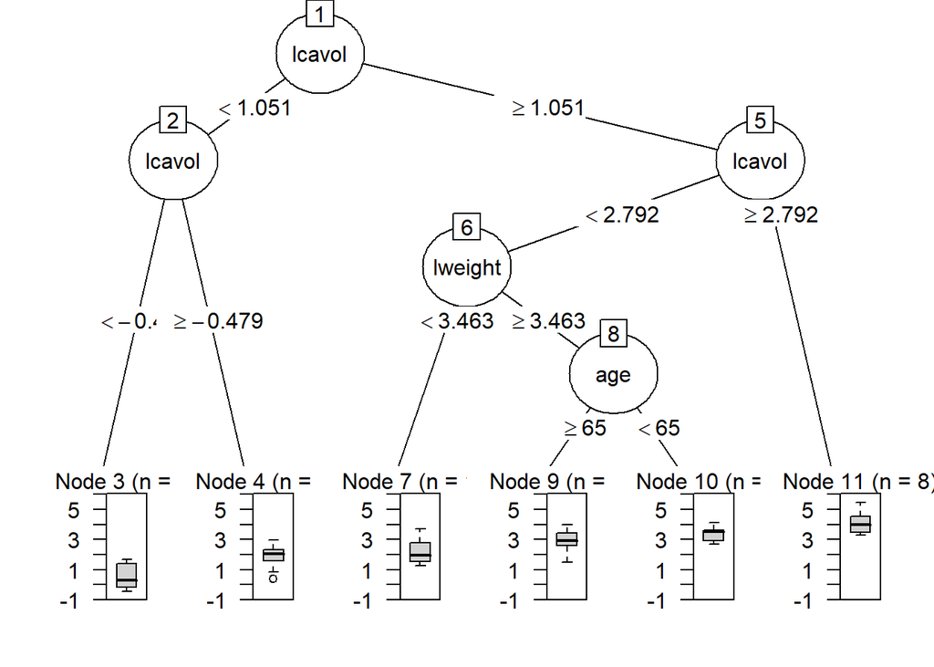

```r
 plot(as.party(tree.pros))
```

The output of the preceding command is as follows: Now we will use the as.party() function for the pruned tree:

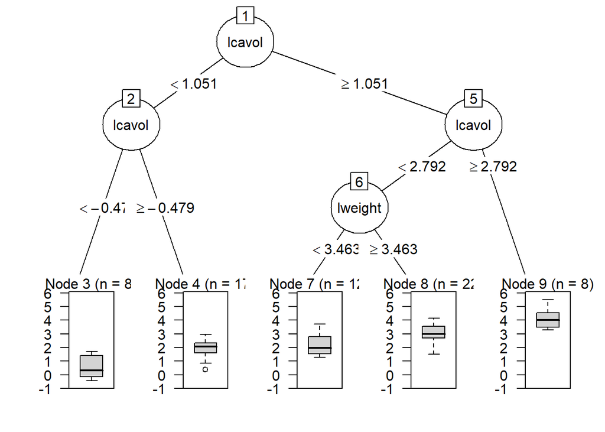

```r
 plot(as.party(prune.tree.pros))
```

The output of the preceding command is as follows:

Note that the splits are exactly the same in the two trees with the exception of the last split, which includes the variable age for the full tree. Interestingly, both the first and second splits in the tree are related to the log of cancer volume (lcavol). These plots are quite informative as they show the splits, nodes, observations per node, and boxplots of the outcome that we are trying to predict.

## Predict on test data

Let’s see how well the pruned tree performs on the test data. What we will do is create an object of the predicted values using the predict() function and incorporate the test data. Then, calculate the errors (the predicted values minus the actual values) and finally, the mean of the squared errors:

```r
 party.pros.test = predict(prune.tree.pros, newdata=pros.test)
```

### Calculate MSE

```r
rpart.resid = party.pros.test - pros.test$lpsa #calculate residuals
mean(rpart.resid^2) #caluclate MSE
```

```
## [1] 0.5267748
```

We have not improved on the predictive value from our work in Chapter 4, Advanced Feature Selection in Linear Models where the baseline MSE was 0.44. However, the technique is not without value. One can look at the tree plots that we produced and easily explain what the primary drivers behind the response are. As mentioned in the introduction, the trees are easy to interpret and explain, which may be more important than accuracy in many cases.

SOURCE: Mastering Machine Learning With - Cory Lesmeister